# AnalisisGralMLBB-ReyerosMarcos-RyRStudio

Marcos Agustín Reyeros

2023-02-19

[figure not shown]

### Descripcion:

En este informe se analizaran las caracateristicas de los personajes del juego “Mobile Legends Bang Bang” tanto de manera general como profundizada para entender de mejor manera las variables del juego.

Se menciona acontinuacion que estamos analizando un dataset que de base contiene nombres de personajes, frase, roles, vida, daño, etc y se muestra acontinuacion un pantallazo de algunas columnas.

```
##               Name Release_Date Primary_Role      Lane   Hp
## 1            Aamon   25/10/2021     Assassin   Jungler 2614
## 2             Akai   14/07/2016         Tank    Roamer 2769
## 3           Aldous   15/05/2018      Fighter  EXP Lane 2718
## 4            Alice   14/07/2016         Mage  EXP Lane 2573
## 5            Alpha   15/05/2017      Fighter  EXP Lane 2646
## 6          Alucard   14/07/2016      Fighter   Jungler 2621
## 7           Angela   06/02/2018      Support    Roamer 2421
## 8            Argus   22/08/2017      Fighter  EXP Lane 2628
## 9            Atlas   20/03/2020         Tank    Roamer 2819
## 10          Aurora   09/05/2017         Mage       Mid 2501
## 11           Aulus   31/08/2021      Fighter  EXP Lane 2758
## 12          Badang   15/01/2019      Fighter  EXP Lane 2708
## 13         Balmond   14/07/2016      Fighter  EXP Lane 2736
## 14            Bane   14/07/2016      Fighter   Jungler 2559
```

[output cut: 100 more lines]

## Roles

En este juego existen distintos roles con los cuales podemos especializarnos en uno de ellos o ir probando y manejar un poco de todo, al ser un juego en equipo es preferente ser especialista en uno y manejar alguno que otro por si la situacion amerita que usemos un rol distinto. Pero si vamos a ser un jugador sin equipo(“que juega siempre partidas con desconocidos”) es preferible manejar todos los roles a pesar de tener un rol de preferencia.

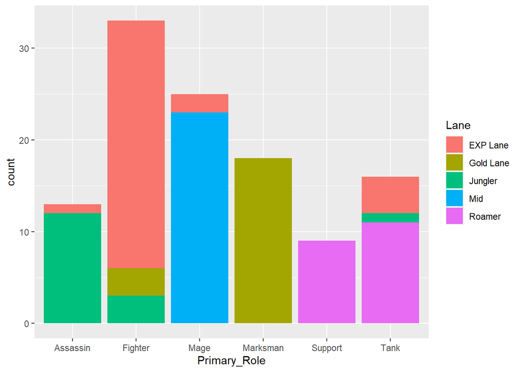

En este grafico de barras podemos observar que en el juego hay 6 roles (Asesino, Combatiente, Mago, Tirador, Soporte y Taque) y podemos observar que hay mas combatientes de personajes para usar, lo cual puede reflejar una tendencia del juego a sacar ese tipo de personajes desde que se creo en 2016 hasta la fecha,cada uno de los personajes tiene una determinada linea en la que mejor se desempeña, recordemos que este juego es una MOBA y la siuacion del juego es que cada personaje se hace cargo de una linea, las cuales pueden ser (Linea de ORO, Linea de EXPERIENCIA, Linea MEDIA, JUNGLA, RECORRER) dependiendo tu función sera la forma de recorrer el mapa del juego.

Para que se vea mejor dejo un mapa del juego a continuacion:

[figure not shown]

## Valores de referecia

```
##        Hp          Hp_Regen           Mana         Mana_Regen
##  Min.   : 918   Min.   : 3.800   Min.   :  0.0   Min.   :  0.00
##  1st Qu.:2501   1st Qu.: 6.800   1st Qu.:100.0   1st Qu.:  4.00
##  Median :2573   Median : 7.200   Median :436.5   Median : 15.00
##  Mean   :2578   Mean   : 7.698   Mean   :339.4   Mean   : 14.93
##  3rd Qu.:2706   3rd Qu.: 8.000   3rd Qu.:490.0   3rd Qu.: 18.00
##  Max.   :2909   Max.   :18.400   Max.   :750.0   Max.   :240.00
##                                                  NA's   :1
##    Phy_Damage      Mag_Damage  Phy_Defence    Mag_Defence      Mov_Speed
##  Min.   : 90.0   Min.   :0    Min.   :10.0   Min.   :10.00   Min.   :240.0
##  1st Qu.:110.0   1st Qu.:0    1st Qu.:17.0   1st Qu.:15.00   1st Qu.:240.0
##  Median :116.5   Median :0    Median :19.0   Median :15.00   Median :251.0
##  Mean   :115.9   Mean   :0    Mean   :19.2   Mean   :14.91   Mean   :251.2
##  3rd Qu.:122.5   3rd Qu.:0    3rd Qu.:22.0   3rd Qu.:15.00   3rd Qu.:260.0
##  Max.   :140.0   Max.   :0    Max.   :27.0   Max.   :15.00   Max.   :270.0
##
```

Usando la funcion “summary” podemos observar, enfocandonos en el minimo, la media y el maximo que por ejemplo:

- VIDA(Hp): Vemos que de 918 a 2909 hay una diferecia muy grande de nivel de vida entre heroes, esto se debe obviamente al rol del personaje e influye mucho a la hora de ver nuestras preferencias de que rol utilizar.

Igualmente a la hora de elegir tambien tendriamos que tener en cuenta las variables de:

- Recuperación de Vida (Hp_Regen)
- Mana(Magia que usan los magos y otros presonajes que tienen habilidade magicas)
- Recuperción de Mana (Mana_Regen)
- Daño Fisico (Phy_Damage)
- Daño Magico (Mag_Damage”no tiene registros de valores todo esta iniciallizado en cero”)
- Defensa Fisica (Phy_Defence)
- Defensa Magica (Mag_Defence)
- Velocidad de Movimiento (Mov_Speed)

## Distincion de Roles

#### + Mayor Promedio de Vida

```
## # A tibble: 6 × 2
##   Primary_Role meanHp
##   <chr>         <dbl>
## 1 Assassin      2560.
## 2 Fighter       2635.
## 3 Mage          2523.
## 4 Marksman      2491.
## 5 Support       2463.
## 6 Tank          2722.
```

En promedio los tanques tienen mayor cantidad de vida.

#### + Mayor Promedio de de Ataque Fisico

```
## # A tibble: 6 × 2
##   Primary_Role AtaqueFisico
##   <chr>               <dbl>
## 1 Assassin             117.
## 2 Fighter              118.
## 3 Mage                 111.
## 4 Marksman             111.
## 5 Support              118.
## 6 Tank                 121.
```

En promedio los tanques tienen mayor cantidad de ataque fisico.

#### + Mayor Promedio de Velocidad de Movimiento

```
## # A tibble: 6 × 2
##   Primary_Role VelocidadMovimiento
##   <chr>                      <dbl>
## 1 Assassin                    257.
## 2 Fighter                     257.
## 3 Mage                        244
## 4 Marksman                    245.
## 5 Support                     247.
## 6 Tank                        256.
```

En promedio los asesinos y combatientes tienen mayor cantidad de velocidad de movimiento.

## Analisis PCA

```
## [1] "sdev"     "rotation" "center"   "scale"    "x"
```

```
## Importance of components:
##                           PC1    PC2    PC3    PC4     PC5     PC6     PC7
## Standard deviation     1.5041 1.4179 1.0623 1.0094 0.91957 0.80345 0.77839
## Proportion of Variance 0.2514 0.2234 0.1254 0.1132 0.09396 0.07173 0.06732
## Cumulative Proportion  0.2514 0.4747 0.6001 0.7133 0.80728 0.87901 0.94633
##                            PC8     PC9
## Standard deviation     0.68822 0.09684
## Proportion of Variance 0.05263 0.00104
## Cumulative Proportion  0.99896 1.00000
```

```
## Principal Components Analysis
## Call: principal(r = mbl2, nfactors = 2, rotate = "none")
## Standardized loadings (pattern matrix) based upon correlation matrix
##               PC1   PC2    h2    u2 com
## Hp           0.61 -0.06 0.378 0.622 1.0
## Hp_Regen     0.64 -0.06 0.419 0.581 1.0
## Mana        -0.43  0.16 0.210 0.790 1.3
## Phy_Damage   0.46 -0.14 0.236 0.764 1.2
## Phy_Defence  0.71  0.02 0.504 0.496 1.0
## Mag_Defence -0.08 -0.10 0.015 0.985 1.9
## Mov_Speed    0.72 -0.11 0.536 0.464 1.0
## Esport_Wins  0.14  0.98 0.987 0.013 1.0
## Esport_Loss  0.13  0.98 0.987 0.013 1.0
##
##                        PC1  PC2
## SS loadings           2.26 2.01
## Proportion Var        0.25 0.22
## Cumulative Var        0.25 0.47
## Proportion Explained  0.53 0.47
## Cumulative Proportion 0.53 1.00
##
## Mean item complexity =  1.2
## Test of the hypothesis that 2 components are sufficient.
##
## The root mean square of the residuals (RMSR) is  0.1
##  with the empirical chi square  76.42  with prob <  7.6e-09
##
## Fit based upon off diagonal values = 0.84
```

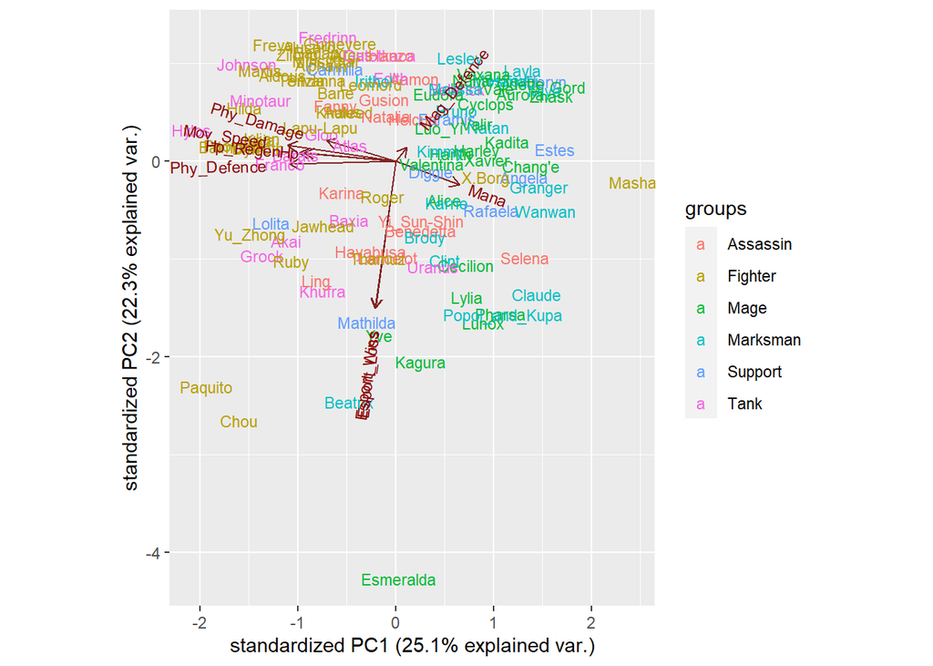

Hay algunos casos excepcionales que tienen explicación en este caso como por ejemplo :

- Masha: Es un combatiente, que su nivel de vida base es bajo pero tiene una cualidad que para vencerlo hay que bajarle la barra de vida 3 veces, por eso es catalogado como un combatiente ademas de que su especialidad es el combate cuerpo a cuerpo y ademas este combatiente usa Mana entonces no es de extrañar esa posicion en el grafico.

## Heroes Gratis

Al iniciar el juego nos regalaran un personaje el cual tiene su rol que por lo general es un tirador llamado “Layla” a medida que seguimos jugabdo nos van regalando personajes de los distintos roles, estos personajes suelen ser los que fueron lanzados con el juego en el mismo año, a veces nos regalan items como para elegir cual queremos.

Tambien mietras mas jugamos nos dan monedas que al juntar una cantidad determinada podemos cambiarlas por el heroe que quieramos. Por lo general los usuarios suelen buscar videos del personaje que quieren obtener para aprender sobre ellos antes de usarlos.

Esta lista nos permite saber cuales nos daran gratis o entre cuales nos haran elegir para oobtenerlos gratis y antes de ello seria ideal buscar informacion sobre como manejarlos para disfrutar mas del juego.

```
##          Release_Date  Relevancia
## Akai       14/07/2016 LANZAMIENTO
## Alice      14/07/2016 LANZAMIENTO
## Alucard    14/07/2016 LANZAMIENTO
## Balmond    14/07/2016 LANZAMIENTO
## Bane       14/07/2016 LANZAMIENTO
## Bruno      14/07/2016 LANZAMIENTO
## Chou       14/07/2016 LANZAMIENTO
## Clint      14/07/2016 LANZAMIENTO
## Eudora     14/07/2016 LANZAMIENTO
## Fanny      14/07/2016 LANZAMIENTO
## Franco     14/07/2016 LANZAMIENTO
## Freya      14/07/2016 LANZAMIENTO
## Gord       14/07/2016 LANZAMIENTO
## Hayabusa   14/07/2016 LANZAMIENTO
## Kagura     14/07/2016 LANZAMIENTO
## Karina     14/07/2016 LANZAMIENTO
## Layla      14/07/2016 LANZAMIENTO
## Lolita     14/07/2016 LANZAMIENTO
## Minotaur   14/07/2016 LANZAMIENTO
## Nana       14/07/2016 LANZAMIENTO
## Rafaela    14/07/2016 LANZAMIENTO
## Zilong     14/07/2016 LANZAMIENTO
```

## Criterios a la hora de comprar heroes

Para el juego hay que tener en cuenta que a la hora de elegir un heroe se puede comprar uno de los que estan disponible o esperar el lanzamiento de un heroe nuevo como saber si esta por llegar un heroe nuevo, a parte de buscar info en las distintas comunidades una forma mas general seria analizar en que mes suelen lanzar un nuevo heroe.

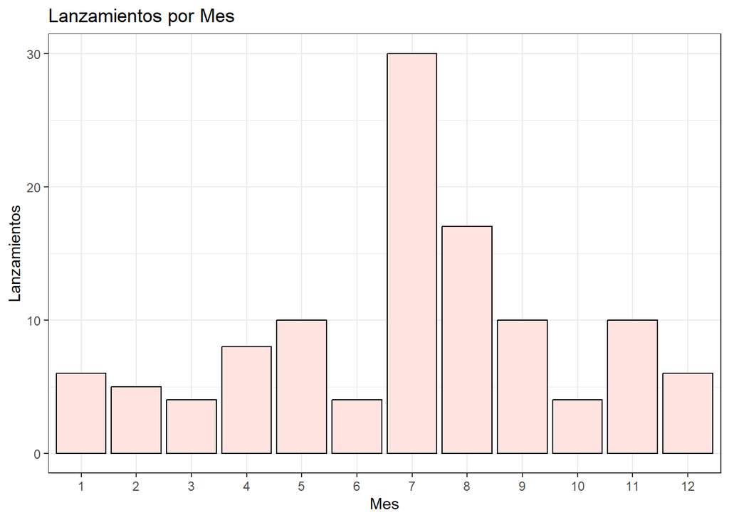

Aqui podemos observar que el mes de julio(07) es el mes con mas frecuencia de lanzamientos de nuevos heroes por lo cual si estamos cerca de ese mes seria lo ideal esperar un poco para elegir.

Tambien hay que tener en cuenta que la frecuencia de heroes nuevos fue cayendo a lo largo de los años y esto se puede observar en el seguiente grafico.

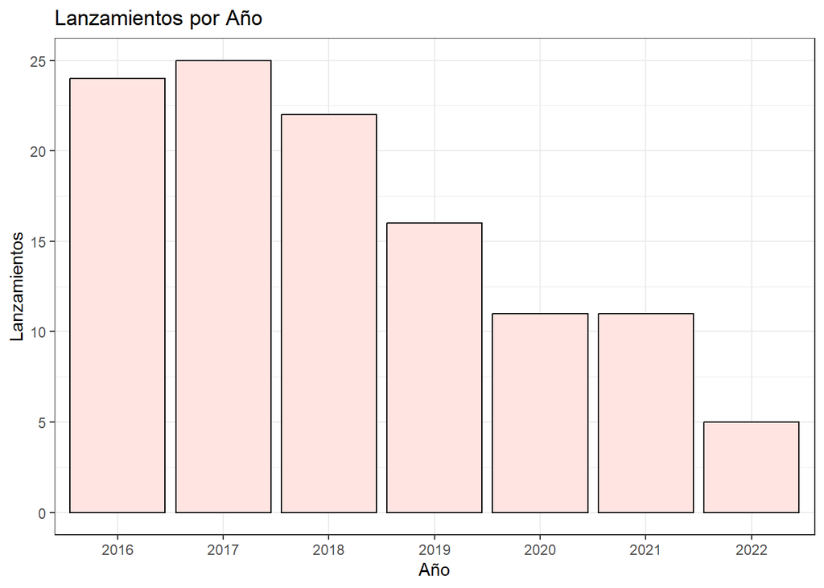